# Lecture 8：ベイズ推定の基礎と部分プーリング

計量経済学II

Kei Ikegami

## 今日の問い

8問しか答えていない顧客の好みを、どう推定するか。

- 全員をまとめれば、個人差が消える。
- 一人ずつ推定すれば、偶然に左右される。
- 本人のデータと、他の人の情報を組み合わせたい。

## 尤度は、パラメータの関数

$$y\mid\theta\sim N(\theta,s^2)$$

- データを固定し、$\theta$ を動かす。
- 観測されたデータが出やすい候補を比較する。
- このモデルの最尤推定値は $\hat\theta=y$。

## 事前分布を加える

$$\theta\sim N(m_0,v_0)$$

$$p(\theta\mid y)\propto L(\theta;y)p(\theta)$$

事前分布は、データを見る前にどの範囲を考えるかを表す。尤度との積を、面積1の分布に直す。

## 精度で重みづけする

$$v_1=(1/s^2+1/v_0)^{-1},\qquad m_1=v_1(y/s^2+m_0/v_0)$$

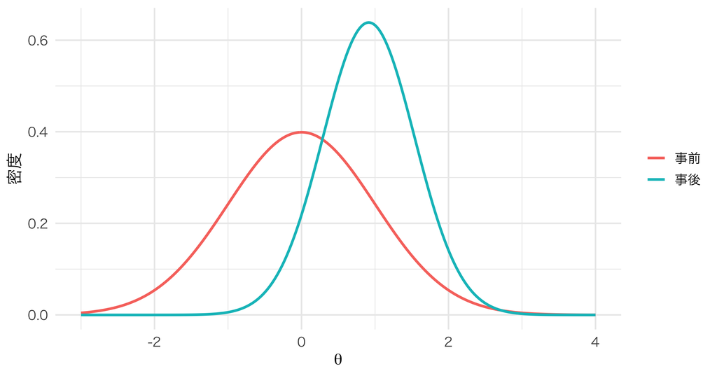

## 区間の対象を分ける

| 対象 | この正規モデルでの分布 |
| --- | --- |
| 平均的評価 $\theta$ | $N(m_1,v_1)$ |
| 次の観測 $y^{new}$ | $N(m_1,v_1+s^2)$ |

信用区間は事後確率についての区間。次の観測には新しいノイズも入る。

## 個人差と測定ノイズ

$$y_i\mid\theta_i\sim N(\theta_i,s_i^2),\qquad\theta_i\sim N(\mu,\tau^2)$$

- $\tau^2$：本当の個人差。
- $s_i^2=\sigma^2/n_i$：平均を測るときのノイズ。

## 3つのpooling

| 方法 | 推定の考え方 |
| --- | --- |
| complete | 全員同じ |
| no pooling | 全員別々 |
| partial | 個人差を残して情報を共有 |

## 縮小の式

$$E[\theta_i\mid y_i,\mu,\tau^2]=B_i\mu+(1-B_i)y_i$$

$$B_i=\frac{s_i^2}{s_i^2+\tau^2}$$

本人の観測が多いほど縮小は弱い。本当の個人差が大きいときも縮小は弱い。

## 経験ベイズ

$y_i\sim N(\mu,\tau^2+s_i^2)$ の周辺尤度で母集団を推定し、固定して個人を推定する。

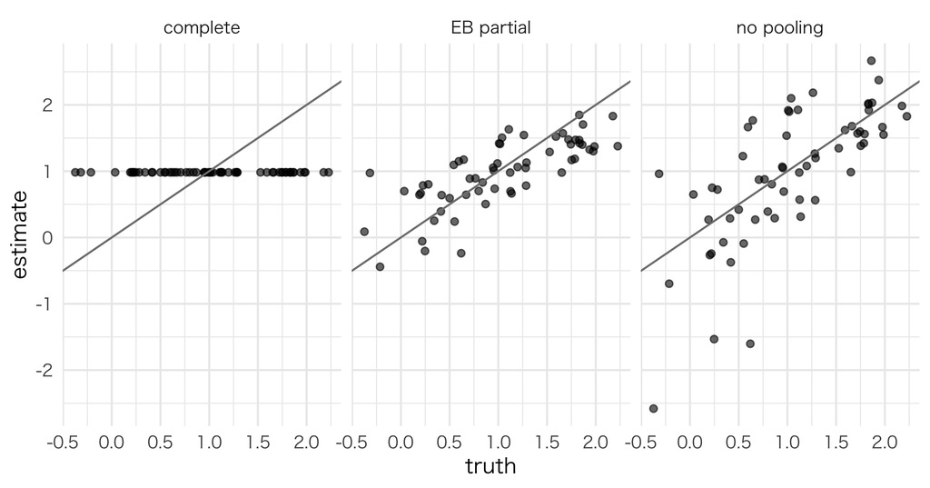

## フルベイズ

$$p(\theta,\mu,\tau^2\mid y)\propto\prod_i p(y_i\mid\theta_i)p(\theta_i\mid\mu,\tau^2)p(\mu)p(\tau^2)$$

母集団パラメータにも事前分布を置く。その不確実性を個人の推定へ伝える。

## Gibbsサンプリング

1. 今の $\mu,\tau^2$ のもとで全員の $\theta_i$ を引く。
2. 今の全員の $\theta_i$ から $\mu$ を引く。
3. 今の個人差から $\tau^2$ を引く。
4. 繰り返し、事後平均や区間を計算する。

点推定値へ止まるための計算ではない。

## 点推定と不確実性

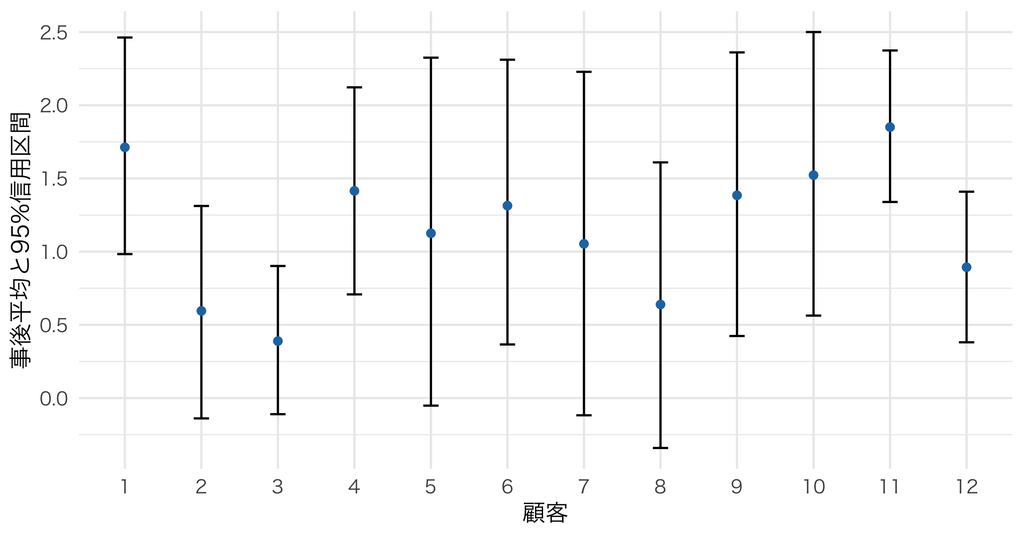

## 既存顧客と新規顧客

- 既存：その人の $\theta_i$ の事後抽出値を使う。
- 新規：各反復の $\mu,\tau$ から新しい $\theta$ を引く。
- 次の観測には、さらに観測ノイズを加える。

## 事例から見る共通点

- 野球の18人・45打数：少ない観測で能力と偶然を区別する。
- 8校の実験：各校の効果と推定誤差を区別する。
- パソコン評価179人：短い回答から個人差を推定する。

出典・モデルの違いは 講義ノート の研究コーナーを参照。

## まとめと次回

尤度 → 事前 → 事後 → 予測。

個人差を共有する母集団、事前分布、未使用データでの予測を確認する。

次回は、評価スコアから選択データへ。階層ベイズで個人のlogitを推定する。